# Risk Factor Analysis

## Outcome Variable

**Outcome Variable:** co_occurence

## Predictor Variables

**Intervention Variable:** ever_underweight06

**Adjustment Set:**

- sex
- arm
- brthmon
- single
- hhwealth_quart
- W_mage
- W_mhtcm
- W_meducyrs
- W_feducyrs
- delta_brthmon
- delta_single
- delta_hhwealth_quart
- delta_W_mage
- delta_W_mhtcm
- delta_W_meducyrs
- delta_W_feducyrs

## Stratifying Variables

The analysis was stratified on these variable(s):

- studyid
- country

## Data Summary

| studyid | country | ever_underweight06 | co_occurence | n_cell | n |
| --- | --- | --- | --- | --- | --- |
| ki0047075b-MAL-ED | BANGLADESH | 0 | 0 | 147 | 221 |
| ki0047075b-MAL-ED | BANGLADESH | 0 | 1 | 3 | 221 |
| ki0047075b-MAL-ED | BANGLADESH | 1 | 0 | 60 | 221 |
| ki0047075b-MAL-ED | BANGLADESH | 1 | 1 | 11 | 221 |
| ki0047075b-MAL-ED | BRAZIL | 0 | 0 | 168 | 180 |
| ki0047075b-MAL-ED | BRAZIL | 0 | 1 | 0 | 180 |
| ki0047075b-MAL-ED | BRAZIL | 1 | 0 | 11 | 180 |
| ki0047075b-MAL-ED | BRAZIL | 1 | 1 | 1 | 180 |
| ki0047075b-MAL-ED | INDIA | 0 | 0 | 130 | 228 |
| ki0047075b-MAL-ED | INDIA | 0 | 1 | 0 | 228 |
| ki0047075b-MAL-ED | INDIA | 1 | 0 | 81 | 228 |
| ki0047075b-MAL-ED | INDIA | 1 | 1 | 17 | 228 |
| ki0047075b-MAL-ED | NEPAL | 0 | 0 | 190 | 229 |
| ki0047075b-MAL-ED | NEPAL | 0 | 1 | 0 | 229 |
| ki0047075b-MAL-ED | NEPAL | 1 | 0 | 35 | 229 |
| ki0047075b-MAL-ED | NEPAL | 1 | 1 | 4 | 229 |
| ki0047075b-MAL-ED | PERU | 0 | 0 | 180 | 222 |
| ki0047075b-MAL-ED | PERU | 0 | 1 | 1 | 222 |
| ki0047075b-MAL-ED | PERU | 1 | 0 | 36 | 222 |
| ki0047075b-MAL-ED | PERU | 1 | 1 | 5 | 222 |
| ki0047075b-MAL-ED | SOUTH AFRICA | 0 | 0 | 199 | 241 |
| ki0047075b-MAL-ED | SOUTH AFRICA | 0 | 1 | 2 | 241 |
| ki0047075b-MAL-ED | SOUTH AFRICA | 1 | 0 | 38 | 241 |
| ki0047075b-MAL-ED | SOUTH AFRICA | 1 | 1 | 2 | 241 |
| ki0047075b-MAL-ED | TANZANIA, UNITED REPUBLIC OF | 0 | 0 | 187 | 225 |
| ki0047075b-MAL-ED | TANZANIA, UNITED REPUBLIC OF | 0 | 1 | 0 | 225 |
| ki0047075b-MAL-ED | TANZANIA, UNITED REPUBLIC OF | 1 | 0 | 37 | 225 |
| ki0047075b-MAL-ED | TANZANIA, UNITED REPUBLIC OF | 1 | 1 | 1 | 225 |
| ki1000108-CMC-V-BCS-2002 | INDIA | 0 | 0 | 188 | 369 |
| ki1000108-CMC-V-BCS-2002 | INDIA | 0 | 1 | 1 | 369 |

[output cut: 78 more lines]

The following strata were considered:

- studyid: ki0047075b-MAL-ED, country: BANGLADESH
- studyid: ki0047075b-MAL-ED, country: BRAZIL
- studyid: ki0047075b-MAL-ED, country: INDIA
- studyid: ki0047075b-MAL-ED, country: NEPAL
- studyid: ki0047075b-MAL-ED, country: PERU
- studyid: ki0047075b-MAL-ED, country: SOUTH AFRICA
- studyid: ki0047075b-MAL-ED, country: TANZANIA, UNITED REPUBLIC OF
- studyid: ki1000108-CMC-V-BCS-2002, country: INDIA
- studyid: ki1000108-IRC, country: INDIA
- studyid: ki1000109-EE, country: PAKISTAN
- studyid: ki1000109-ResPak, country: PAKISTAN
- studyid: ki1000304b-SAS-CompFeed, country: INDIA
- studyid: ki1000304b-SAS-FoodSuppl, country: INDIA
- studyid: ki1017093-NIH-Birth, country: BANGLADESH
- studyid: ki1017093b-PROVIDE, country: BANGLADESH
- studyid: ki1017093c-NIH-Crypto, country: BANGLADESH
- studyid: ki1066203-TanzaniaChild2, country: TANZANIA, UNITED REPUBLIC OF
- studyid: ki1101329-Keneba, country: GAMBIA
- studyid: ki1113344-GMS-Nepal, country: NEPAL
- studyid: ki1114097-CMIN, country: BANGLADESH
- studyid: ki1114097-CONTENT, country: PERU
- studyid: ki1119695-PROBIT, country: BELARUS
- studyid: ki1126311-ZVITAMBO, country: ZIMBABWE
- studyid: ki1135781-COHORTS, country: GUATEMALA
- studyid: ki1135781-COHORTS, country: PHILIPPINES
- studyid: ki1148112-LCNI-5, country: MALAWI
- studyid: kiGH5241-JiVitA-4, country: BANGLADESH

### Dropped Strata

Some strata were dropped due to rare outcomes:

- studyid: ki0047075b-MAL-ED, country: BANGLADESH
- studyid: ki0047075b-MAL-ED, country: BRAZIL
- studyid: ki0047075b-MAL-ED, country: INDIA
- studyid: ki0047075b-MAL-ED, country: NEPAL
- studyid: ki0047075b-MAL-ED, country: PERU
- studyid: ki0047075b-MAL-ED, country: SOUTH AFRICA
- studyid: ki0047075b-MAL-ED, country: TANZANIA, UNITED REPUBLIC OF
- studyid: ki1000108-CMC-V-BCS-2002, country: INDIA
- studyid: ki1000108-IRC, country: INDIA
- studyid: ki1000109-EE, country: PAKISTAN
- studyid: ki1000109-ResPak, country: PAKISTAN
- studyid: ki1114097-CMIN, country: BANGLADESH
- studyid: ki1114097-CONTENT, country: PERU
- studyid: ki1119695-PROBIT, country: BELARUS

## Methods Detail

We’re interested in the causal parameters $E[Y_a]$ for all values of $a \in \mathcal{A}$. These parameters represent the mean outcome if, possibly contrary to fact, we intervened to set all units to have $A=a$. Under the randomization and positivity assumptions, these are identified by the statistical parameters $\psi_a=E_W[E_{Y|A,W}(Y|A=a,W)]$. In addition, we’re interested in the mean of $Y$, $E[Y]$ under no intervention (the observed mean). We will estimate these parameters by using SuperLearner to fit the relevant likelihood factors – $E_{Y|A,W}(Y|A=a,W)$ and $p(A=a|W)$, and then updating our likelihood fit using a joint TMLE.

For unadjusted analyses ($W=\{\}$), initial likelihoods were estimated using Lrnr_glm to estimate the simple $E(Y|A)$ and Lrnr_mean to estimate $p(A)$. For adjusted analyses, a small library containing Lrnr_glmnet, Lrnr_xgboost, and Lrnr_mean was used.

Having estimated these parameters, we will then use the delta method to estimate relative risks and attributable risks relative to a prespecified baseline level of $A$.

# Results Detail

## Results Plots

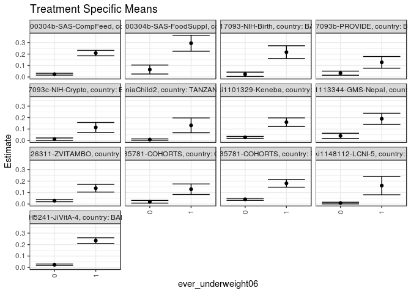

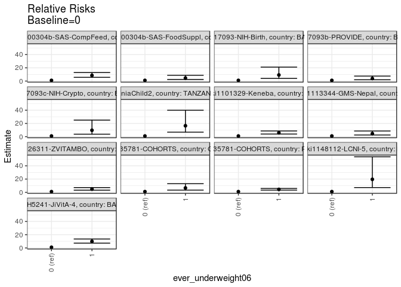

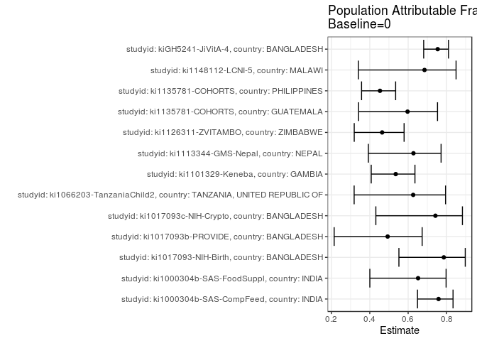

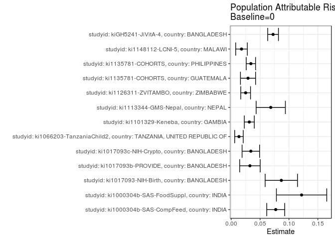

## Results Table

### Parameter: TSM

| studyid | country | intervention_level | baseline_level | estimate | ci_lower | ci_upper |
| --- | --- | --- | --- | --- | --- | --- |
| ki1000304b-SAS-CompFeed | INDIA | 0 | NA | 0.0245232 | 0.0164102 | 0.0326362 |
| ki1000304b-SAS-CompFeed | INDIA | 1 | NA | 0.2084687 | 0.1847544 | 0.2321829 |
| ki1000304b-SAS-FoodSuppl | INDIA | 0 | NA | 0.0650758 | 0.0258225 | 0.1043291 |
| ki1000304b-SAS-FoodSuppl | INDIA | 1 | NA | 0.2944342 | 0.2246838 | 0.3641846 |
| ki1017093-NIH-Birth | BANGLADESH | 0 | NA | 0.0236220 | 0.0049252 | 0.0423189 |
| ki1017093-NIH-Birth | BANGLADESH | 1 | NA | 0.2163462 | 0.1603287 | 0.2723636 |
| ki1017093b-PROVIDE | BANGLADESH | 0 | NA | 0.0333110 | 0.0153957 | 0.0512263 |
| ki1017093b-PROVIDE | BANGLADESH | 1 | NA | 0.1278484 | 0.0770091 | 0.1786877 |
| ki1017093c-NIH-Crypto | BANGLADESH | 0 | NA | 0.0117925 | 0.0015091 | 0.0220758 |
| ki1017093c-NIH-Crypto | BANGLADESH | 1 | NA | 0.1142857 | 0.0712208 | 0.1573507 |
| ki1066203-TanzaniaChild2 | TANZANIA, UNITED REPUBLIC OF | 0 | NA | 0.0080092 | 0.0020968 | 0.0139215 |
| ki1066203-TanzaniaChild2 | TANZANIA, UNITED REPUBLIC OF | 1 | NA | 0.1320755 | 0.0675890 | 0.1965620 |
| ki1101329-Keneba | GAMBIA | 0 | NA | 0.0271894 | 0.0188471 | 0.0355317 |
| ki1101329-Keneba | GAMBIA | 1 | NA | 0.1599121 | 0.1228234 | 0.1970009 |
| ki1113344-GMS-Nepal | NEPAL | 0 | NA | 0.0406184 | 0.0182043 | 0.0630324 |
| ki1113344-GMS-Nepal | NEPAL | 1 | NA | 0.1893313 | 0.1411150 | 0.2375476 |
| ki1126311-ZVITAMBO | ZIMBABWE | 0 | NA | 0.0288020 | 0.0197236 | 0.0378805 |
| ki1126311-ZVITAMBO | ZIMBABWE | 1 | NA | 0.1378277 | 0.1041345 | 0.1715208 |
| ki1135781-COHORTS | GUATEMALA | 0 | NA | 0.0196628 | 0.0081507 | 0.0311750 |
| ki1135781-COHORTS | GUATEMALA | 1 | NA | 0.1290070 | 0.0831801 | 0.1748340 |
| ki1135781-COHORTS | PHILIPPINES | 0 | NA | 0.0411177 | 0.0322971 | 0.0499384 |
| ki1135781-COHORTS | PHILIPPINES | 1 | NA | 0.1803006 | 0.1468430 | 0.2137582 |
| ki1148112-LCNI-5 | MALAWI | 0 | NA | 0.0081833 | 0.0010347 | 0.0153319 |
| ki1148112-LCNI-5 | MALAWI | 1 | NA | 0.1604938 | 0.0804992 | 0.2404884 |
| kiGH5241-JiVitA-4 | BANGLADESH | 0 | NA | 0.0236340 | 0.0168078 | 0.0304601 |
| kiGH5241-JiVitA-4 | BANGLADESH | 1 | NA | 0.2345111 | 0.2097249 | 0.2592973 |

### Parameter: E(Y)

| studyid | country | intervention_level | baseline_level | estimate | ci_lower | ci_upper |
| --- | --- | --- | --- | --- | --- | --- |
| ki1000304b-SAS-CompFeed | INDIA | NA | NA | 0.1015873 | 0.0902183 | 0.1129563 |
| ki1000304b-SAS-FoodSuppl | INDIA | NA | NA | 0.1869159 | 0.1442025 | 0.2296293 |
| ki1017093-NIH-Birth | BANGLADESH | NA | NA | 0.1103896 | 0.0817833 | 0.1389959 |
| ki1017093b-PROVIDE | BANGLADESH | NA | NA | 0.0657194 | 0.0452330 | 0.0862057 |
| ki1017093c-NIH-Crypto | BANGLADESH | NA | NA | 0.0457413 | 0.0294659 | 0.0620168 |
| ki1066203-TanzaniaChild2 | TANZANIA, UNITED REPUBLIC OF | NA | NA | 0.0214286 | 0.0123577 | 0.0304995 |
| ki1101329-Keneba | GAMBIA | NA | NA | 0.0585078 | 0.0478474 | 0.0691682 |
| ki1113344-GMS-Nepal | NEPAL | NA | NA | 0.1090909 | 0.0830130 | 0.1351688 |
| ki1126311-ZVITAMBO | ZIMBABWE | NA | NA | 0.0537825 | 0.0430304 | 0.0645346 |
| ki1135781-COHORTS | GUATEMALA | NA | NA | 0.0487805 | 0.0336441 | 0.0639169 |
| ki1135781-COHORTS | PHILIPPINES | NA | NA | 0.0751910 | 0.0648251 | 0.0855569 |
| ki1148112-LCNI-5 | MALAWI | NA | NA | 0.0260116 | 0.0141438 | 0.0378793 |
| kiGH5241-JiVitA-4 | BANGLADESH | NA | NA | 0.0961073 | 0.0860713 | 0.1061434 |

### Parameter: RR

| studyid | country | intervention_level | baseline_level | estimate | ci_lower | ci_upper |
| --- | --- | --- | --- | --- | --- | --- |
| ki1000304b-SAS-CompFeed | INDIA | 0 | 0 | 1.000000 | 1.000000 | 1.000000 |
| ki1000304b-SAS-CompFeed | INDIA | 1 | 0 | 8.500884 | 5.627663 | 12.841040 |
| ki1000304b-SAS-FoodSuppl | INDIA | 0 | 0 | 1.000000 | 1.000000 | 1.000000 |
| ki1000304b-SAS-FoodSuppl | INDIA | 1 | 0 | 4.524481 | 2.363645 | 8.660748 |
| ki1017093-NIH-Birth | BANGLADESH | 0 | 0 | 1.000000 | 1.000000 | 1.000000 |
| ki1017093-NIH-Birth | BANGLADESH | 1 | 0 | 9.158654 | 3.982549 | 21.062122 |
| ki1017093b-PROVIDE | BANGLADESH | 0 | 0 | 1.000000 | 1.000000 | 1.000000 |
| ki1017093b-PROVIDE | BANGLADESH | 1 | 0 | 3.838025 | 1.963585 | 7.501807 |
| ki1017093c-NIH-Crypto | BANGLADESH | 0 | 0 | 1.000000 | 1.000000 | 1.000000 |
| ki1017093c-NIH-Crypto | BANGLADESH | 1 | 0 | 9.691429 | 3.748225 | 25.058208 |
| ki1066203-TanzaniaChild2 | TANZANIA, UNITED REPUBLIC OF | 0 | 0 | 1.000000 | 1.000000 | 1.000000 |
| ki1066203-TanzaniaChild2 | TANZANIA, UNITED REPUBLIC OF | 1 | 0 | 16.490566 | 6.805473 | 39.958836 |
| ki1101329-Keneba | GAMBIA | 0 | 0 | 1.000000 | 1.000000 | 1.000000 |
| ki1101329-Keneba | GAMBIA | 1 | 0 | 5.881413 | 4.007582 | 8.631393 |
| ki1113344-GMS-Nepal | NEPAL | 0 | 0 | 1.000000 | 1.000000 | 1.000000 |
| ki1113344-GMS-Nepal | NEPAL | 1 | 0 | 4.661226 | 2.537828 | 8.561267 |
| ki1126311-ZVITAMBO | ZIMBABWE | 0 | 0 | 1.000000 | 1.000000 | 1.000000 |
| ki1126311-ZVITAMBO | ZIMBABWE | 1 | 0 | 4.785344 | 3.210623 | 7.132422 |
| ki1135781-COHORTS | GUATEMALA | 0 | 0 | 1.000000 | 1.000000 | 1.000000 |
| ki1135781-COHORTS | GUATEMALA | 1 | 0 | 6.560962 | 3.306973 | 13.016803 |
| ki1135781-COHORTS | PHILIPPINES | 0 | 0 | 1.000000 | 1.000000 | 1.000000 |
| ki1135781-COHORTS | PHILIPPINES | 1 | 0 | 4.384984 | 3.303652 | 5.820251 |
| ki1148112-LCNI-5 | MALAWI | 0 | 0 | 1.000000 | 1.000000 | 1.000000 |
| ki1148112-LCNI-5 | MALAWI | 1 | 0 | 19.612346 | 7.173595 | 53.619434 |
| kiGH5241-JiVitA-4 | BANGLADESH | 0 | 0 | 1.000000 | 1.000000 | 1.000000 |
| kiGH5241-JiVitA-4 | BANGLADESH | 1 | 0 | 9.922624 | 7.291112 | 13.503902 |

### Parameter: PAR

| studyid | country | intervention_level | baseline_level | estimate | ci_lower | ci_upper |
| --- | --- | --- | --- | --- | --- | --- |
| ki1000304b-SAS-CompFeed | INDIA | 0 | NA | 0.0770641 | 0.0615188 | 0.0926094 |
| ki1000304b-SAS-FoodSuppl | INDIA | 0 | NA | 0.1218401 | 0.0782436 | 0.1654365 |
| ki1017093-NIH-Birth | BANGLADESH | 0 | NA | 0.0867676 | 0.0587762 | 0.1147589 |
| ki1017093b-PROVIDE | BANGLADESH | 0 | NA | 0.0324084 | 0.0146514 | 0.0501653 |
| ki1017093c-NIH-Crypto | BANGLADESH | 0 | NA | 0.0339489 | 0.0188096 | 0.0490881 |
| ki1066203-TanzaniaChild2 | TANZANIA, UNITED REPUBLIC OF | 0 | NA | 0.0134194 | 0.0060109 | 0.0208280 |
| ki1101329-Keneba | GAMBIA | 0 | NA | 0.0313184 | 0.0226816 | 0.0399551 |
| ki1113344-GMS-Nepal | NEPAL | 0 | NA | 0.0684725 | 0.0431549 | 0.0937902 |
| ki1126311-ZVITAMBO | ZIMBABWE | 0 | NA | 0.0249805 | 0.0165099 | 0.0334510 |
| ki1135781-COHORTS | GUATEMALA | 0 | NA | 0.0291177 | 0.0160339 | 0.0422015 |
| ki1135781-COHORTS | PHILIPPINES | 0 | NA | 0.0340733 | 0.0260024 | 0.0421441 |
| ki1148112-LCNI-5 | MALAWI | 0 | NA | 0.0178283 | 0.0077434 | 0.0279131 |
| kiGH5241-JiVitA-4 | BANGLADESH | 0 | NA | 0.0724733 | 0.0631620 | 0.0817847 |

### Parameter: PAF

| studyid | country | intervention_level | baseline_level | estimate | ci_lower | ci_upper |
| --- | --- | --- | --- | --- | --- | --- |
| ki1000304b-SAS-CompFeed | INDIA | 0 | NA | 0.7586000 | 0.6487436 | 0.8340985 |
| ki1000304b-SAS-FoodSuppl | INDIA | 0 | NA | 0.6518445 | 0.4003235 | 0.7978706 |
| ki1017093-NIH-Birth | BANGLADESH | 0 | NA | 0.7860120 | 0.5519125 | 0.8978082 |
| ki1017093b-PROVIDE | BANGLADESH | 0 | NA | 0.4931330 | 0.2142998 | 0.6730124 |
| ki1017093c-NIH-Crypto | BANGLADESH | 0 | NA | 0.7421926 | 0.4316899 | 0.8830486 |
| ki1066203-TanzaniaChild2 | TANZANIA, UNITED REPUBLIC OF | 0 | NA | 0.6262395 | 0.3184894 | 0.7950187 |
| ki1101329-Keneba | GAMBIA | 0 | NA | 0.5352857 | 0.4074657 | 0.6355326 |
| ki1113344-GMS-Nepal | NEPAL | 0 | NA | 0.6276650 | 0.3926332 | 0.7717469 |
| ki1126311-ZVITAMBO | ZIMBABWE | 0 | NA | 0.4644719 | 0.3189253 | 0.5789150 |
| ki1135781-COHORTS | GUATEMALA | 0 | NA | 0.5969122 | 0.3417609 | 0.7531599 |
| ki1135781-COHORTS | PHILIPPINES | 0 | NA | 0.4531561 | 0.3571281 | 0.5348401 |
| ki1148112-LCNI-5 | MALAWI | 0 | NA | 0.6853973 | 0.3407366 | 0.8498706 |
| kiGH5241-JiVitA-4 | BANGLADESH | 0 | NA | 0.7540876 | 0.6810451 | 0.8104030 |